# Настройки сети в Linux

Майоров Дмитрий Андреевич

# Информация

## Докладчик

- Майоров Дмитрий Андреевич

# Цель работы

Получить навыки настройки сетевых параметров системы

# Выполнение лабораторной работы

Получаем полномочия администратора. Выводим на экран информацию о существующих сетевых подключениях, а также статистику о количестве отправленных пакетов и связанных с ними сообщениях об ошибках. Команда выводит основную информацию об интерфейсе(номер интерфейса, его имя, флаги состояния, состояние. Статистику приема и статистику передачи)

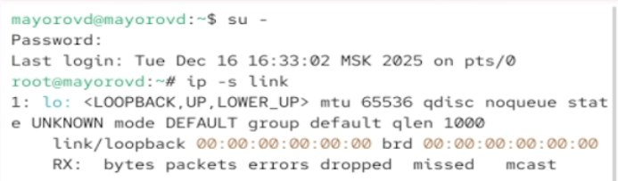

Рисунок 1

# Выполнение лабораторной работы

Выводим на экран информацию о текущих маршрутах. Команда выводит маршрут по умолчанию, локальную сеть, другие сети и специальные маршруты

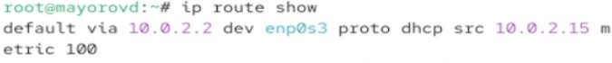

Рисунок 2

# Выполнение лабораторной работы

Выводим на экран информацию о текущих назначениях адресов для сетевых интерфейсов на устройстве. Команда выводит общую информацию, MAC-адрес, IPv4 адреса и IPv6 адреса

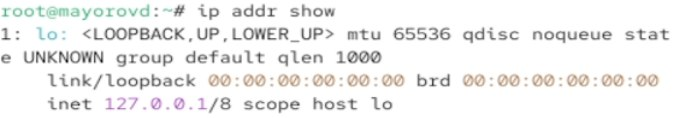

Рисунок 3

# Выполнение лабораторной работы

Отправляем 4 пакета на IP-адрес 8.8.8.8

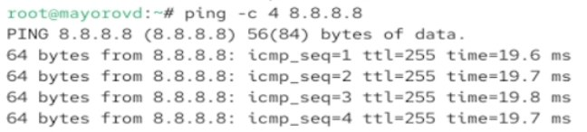

Рисунок 4

# Выполнение лабораторной работы

Добавляем дролнительный адрес к интерфейсу. Проверяем что он добавился

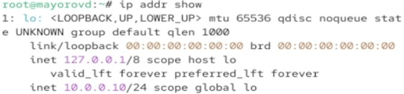

Рисунок 6

# Выполнение лабораторной работы

Вводим команду ifconfig. В отличии от утилиты ip эта команда показывает меньше деталей, не показывает некоторые современные флагм и может не показывать все интерфейсы

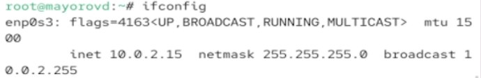

Рисунок 7

# Выполнение лабораторной работы

Выводим на экран список всех прослушиваемых системой портов UDP и TCP

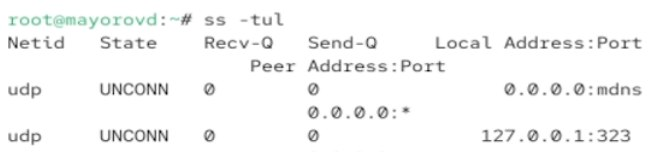

Рисунок 8

# Выполнение лабораторной работы

Выводим на экран информацию о текущих соединениях

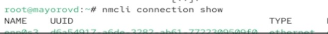

Рисунок 9

# Выполнение лабораторной работы

Добавляем Ethernet-соединение с именем dhcp к интерфейсу

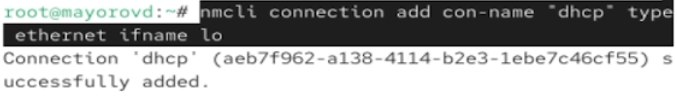

Рисунок 10